# Settling in France: First days in France

Overview of pending bureaucracy and how to get stuff for the new room

french bureaucracy

Nancy

going to France

Published

October 14, 2021

> There is a ton of bureaucracy to do just after arriving to France!

These are the topics I will be covering in the following posts.

- [Registering the French Visa](https://luisavasquez.github.io/quiescens-lct/posts/2021-10-16-registering-french-visa.html)
- [Getting a French phone number](https://luisavasquez.github.io/quiescens-lct/posts/2021-10-31-telephone-france.html)
- [Learning to use the transportation system in Nancy](https://luisavasquez.github.io/quiescens-lct/posts/2021-10-26-transport-nancy.html)
- [Registering at the University of Lorraine](https://luisavasquez.github.io/quiescens-lct/posts/2021-11-02-registering_university_lorraine.html)
- [Setting up access to the University of Lorraine Wifi Network](https://luisavasquez.github.io/quiescens-lct/posts/2021-11-19-eduroam.html)
- [Setting up a bank account](https://luisavasquez.github.io/quiescens-lct/posts/2021-11-14-bank_account.html)
- [Getting vaccinated against COVID in France and using the *passe sanitaire*](https://luisavasquez.github.io/quiescens-lct/posts/2021-11-29-covid_stuff.html)
- [Registering into the French public health system](https://luisavasquez.github.io/quiescens-lct/posts/2021-11-24-french_healtcare.html)
- [Applying for and getting housing subsidies](https://luisavasquez.github.io/quiescens-lct/posts/2021-12-02-caf.html)

And that’s to be done independently of classes! That’s why I arrived two weeks early to France: to have enough time for bureaucracy.

Additionally, since I did not know how long creating a bank account would take, I took a bunch of cash with me (around 2000 €).

In this post, I will just cover a simpler topic: **getting groceries and house appliances** during the first days.

You will find out that buying lunch and dinner daily in Nancy is not sustainable with a student budget, so, better start getting everything to cook at home soon!

# Getting a cheap meal

Until you get your student card (and the student restaurants open), you will not be able to get student meals. Thus for the first weeks you will have to consider other options.

In Northern Europe, Turkish and Arabic fast food is cheap and easy to find. There are a couple of *Kebab*/*Shawerma* spots close to Residence Batelière.

> Note that by “cheap” I mean around 7 € for each meal.

Just search “kebab” in Google Maps and you will find a bunch of them in the city. Around four kebab shops are within walking distance (< 20 min.) from Batelière.

As I was getting groceries and house appliances for my room, I lived off Turkish food for around three days.

# Getting groceries

There are a couple of supermarkets within reasonable distance of Residence Bateliêre.

- *Lidl* is a European supermarket chain know for its **very low prices**, and luckily, there is one very close to the Residence Batelière, just two blocks away:

[interactive chart not shown]

They don’t have much variety, but the prices are good and you can find there most of the basic stuff.

Plus, *that* specific Lidl close to Batelière is one of the few supermarkets that opens on Sunday (until midday)!

- *Carrefour* is a French supermarket chain, they have more variety than Lidl but their prices are a little higher (not crazy high though).

There is one Carrefour about four blocks away from Residence Bateliêre:

[interactive chart not shown]

- Finally, there is an *ALDI*, another European supermarket brand with cheap prices, about ten blocks away from the residence.

Since their products are basically the same as those in Lidl, I never buy at that ALDI.

[interactive chart not shown]

Nancy is a pretty walkable city, so I would recommend getting one of these trolleys for buying groceries:

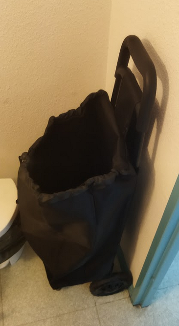

As time passed, I found out about other places to get good groceries, I will talk about it in a future post.

# Getting house appliances

## At a supermarket

The supermarkets close to the Residence Batelière are decent enough to get groceries, but to get house appliances at reasonable prices, you have to got to the big supermarkets (in French *hypermachés*).

Granted, getting there needs knowledge on using the [transportation system](https://luisavasquez.github.io/quiescens-lct/posts/2021-10-26-transport-nancy.html).

- *Auchan* is a French supermarket chain, and it has one hypermarket at the edge of Nancy. As the city is small, it does not take long to get there (as it would in other cities).

Here I could get some pots, dishes, utensils, spices, personal hygene items, bed sheets, and cleaning utensils. Actually, here’s where I got the trolley that I mentioned before.

[interactive chart not shown]

- There is also *GiFi*, which is a domestic appliances stores. It is to the south of Nancy.

Here, I could get bed sheets, brooms, a good knife, a mirror, a lamp, electric extensions, and some tools.

[interactive chart not shown]

(Note, to get to GiFi I prefer to get the T2 bus line and then the T4)

## Buying second-hand

- By far **EMMAUS** is your best option for getting house appliances (and thrifting clothes!). They have everything: dishes, cooking utensils, tools, pots, pans, etc. Since they are a charity, the prices are really, really low.

[interactive chart not shown]

- *HappyCash* is a second hand electronic appliances store. They sell them in decent condition for good prices.

There is one HappyCash just next to the GiFi mentioned in the previous section (and half a block away there is an ALDI).

At HappyCash I could get phone chargers, USB cables, electric adaptors, etc.

[interactive chart not shown]

- [Leboncoin](https://www.leboncoin.fr/) (“the good corner”) is a website for people buying and selling all kinds of stuff, like a “French ebay”.

## From students leaving

There are a ton of university students coming to and moving out from Nancy. When they leave the city, they usually leave their stuff at a very good price.

> The problem is knowing who is leaving what.

You may find Facebook groups, but it is easier to know from friends of friends. Of course, when I just arrived I didn’t know anyone in the city.

As I mentioned before, some time before leaving Peru I joined a Whatsapp group of Peruvians coming to study in France at the time as me. Eventually I found out that a couple of them were also going to Nancy. It was through this friends that I found out about some students moving out and selling their stuff.

That’s how I got some pots, a cutting board, and a microwave (for 15 €!)